# Supports graphiques du journal du Stress Hydrique

Manon Tobias m.tobias@institut-rhodanien.com

2024-07-08

# Journal du stress hydrique

Vous trouverez ci-dessous les graphiques et les informations nécessaires au suivi de la contrainte hydrique.  
Vous pourrez donc retrouver :  
- Un point météo  
- Le bilan hydrique et les simulations de l’évolution des réserves en eau dans les sols pour les communes qui vous concernent.  
- Les suivis d’apex, si les parcelles sont suivies  
- Les données des sondes capacitives, si les parcelles sont équipées  
- Les données d’un tensiomètre installé à Vénéjan, pour avoir des informations complémentaires

Les parcelles suivies sont les suivantes:

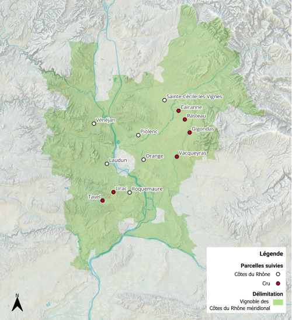

# Météo

[figure not shown]

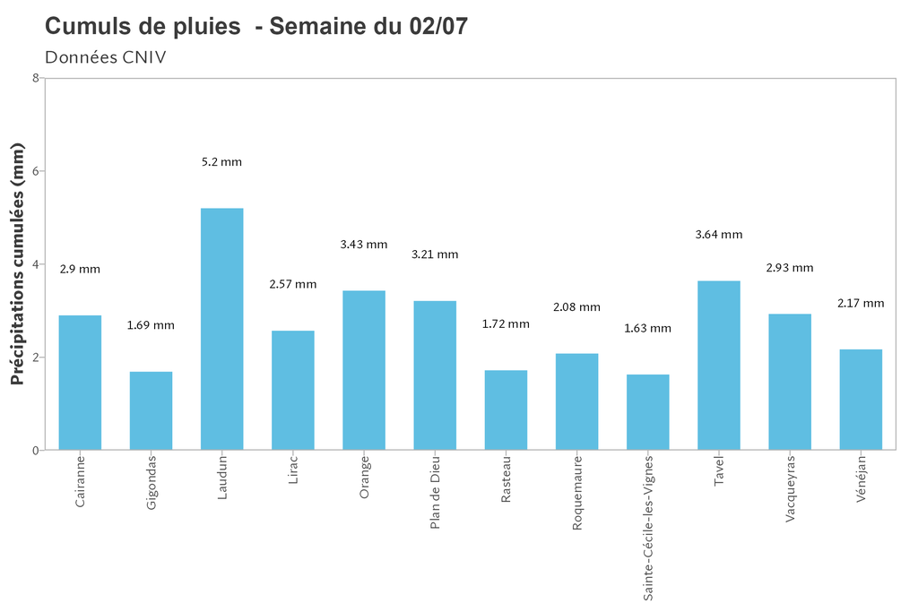

[figure not shown]

# Bilan hydrique et FTSW

Vous trouverez dans cette partie la modélisation des bilans hydriques et de la FTSW, ou la fraction d’eau disponible dans le sol. Ce sont des données modélisées et peuvent donc présenter des différences avec la réalité.

Bilans hydriques : Ci-dessous, le Bilan Hydrique pour les parcelles du réseau. Pour plus d’informations sur les bilans hydriques voir la fiche : lire un bilan hydrique. [**Fiche technique : Comment lire un bilan hydrique ?**](https://www.institut-rhodanien.com/article/fiche-technique-lire-un-bilan-hydrique)

FTSW : Proportion d’eau disponible dans le sol Les pluies depuis le début de l’année ayant été importants, le pourcentage initial d’eau disponible dans le sol a été estimé à environ 100%.Ces informations sont confirmées par les mesures de sondes capacitives. Ces graphiques représentent la proportion d’eau disponible dans le sol théorique (calculée en fonction des données météo).

Vous pouvez cliquer sur les graphiques pour les agrandir.

### Cairanne

[figure not shown]

### Gigondas

[figure not shown]

### Laudun

[figure not shown]

### Lirac

[figure not shown]

### Orange

[figure not shown]

### Plan de Dieu

[figure not shown]

### Rasteau

[figure not shown]

### Roquemaure

[figure not shown]

### Tavel

[figure not shown]

### Vacqueyras

[figure not shown]

### Vénéjan

[figure not shown]

# Suivi d’apex

### Vue d’ensemble

L’observation des apex permet d’estimer le niveau de stress hydrique de la vigne.  
Consultez ici la fiche explicative de la méthode des apex : [**Fiche technique : la méthode des apex**](https://www.institut-rhodanien.com/article/fiche-technique-la-methode-des-apex)

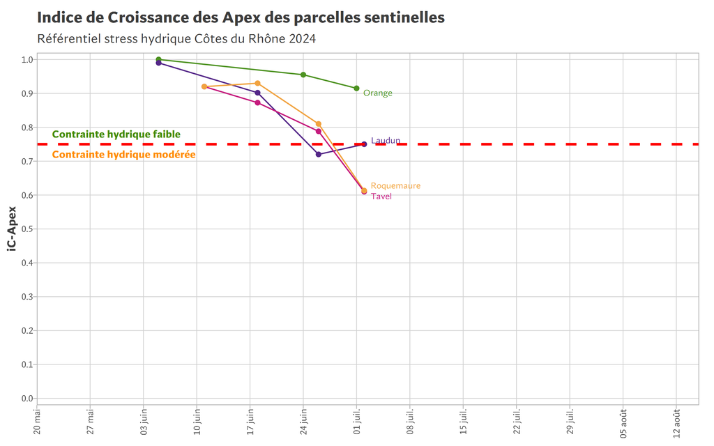

État de l’indice de croissance des apex sur les parcelles suivies

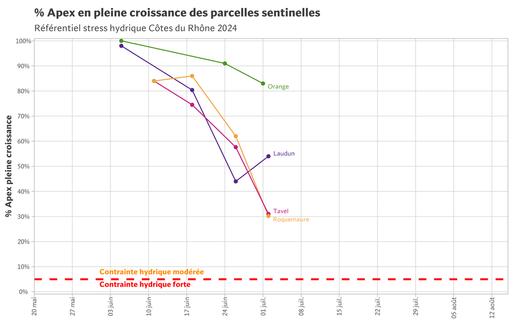

Pourcentage d’apex en croissance sur les parcelles suivies

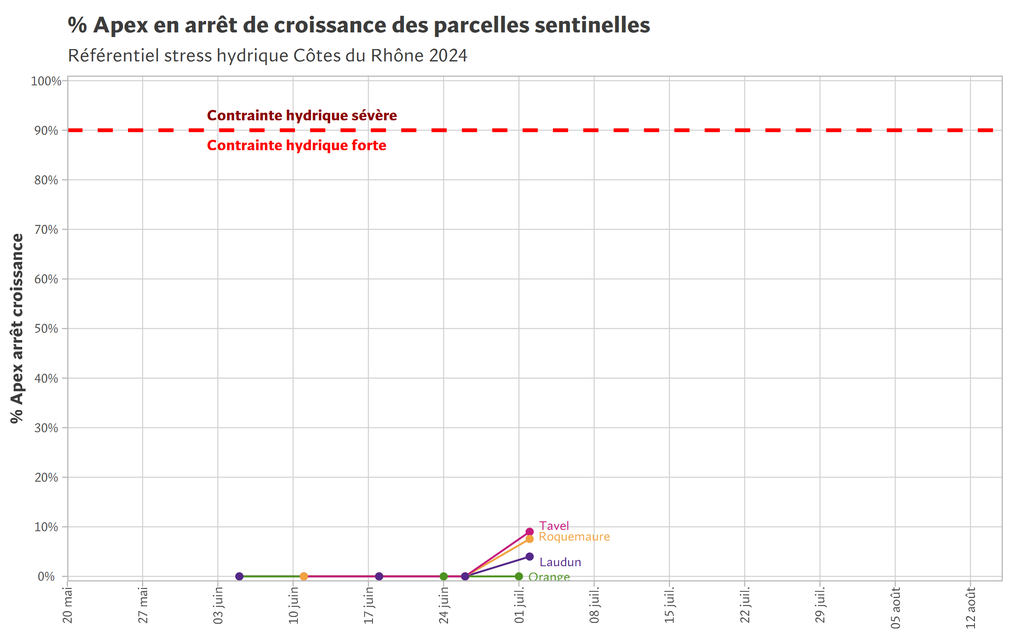

Pourcentage d’apex arrêtés sur les parcelles suivies

Ci-dessous, vous trouverez les graphiques d’apex pour les parcelles qui sont suivies. Toutes les parcelles du réseau ne sont plus suivies.

### Laudun

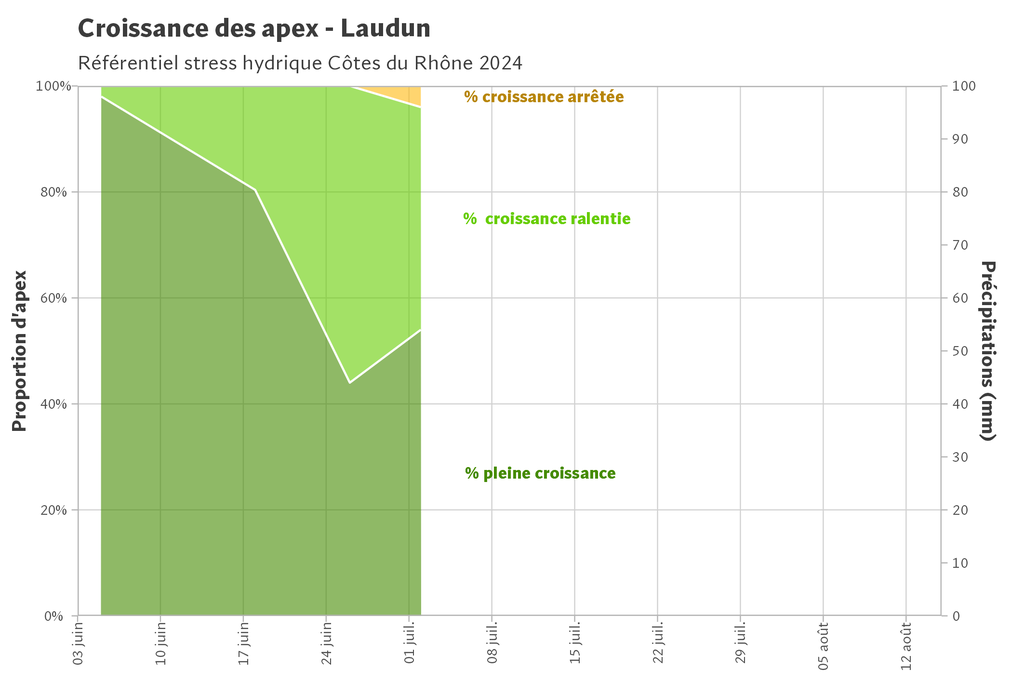

### Orange

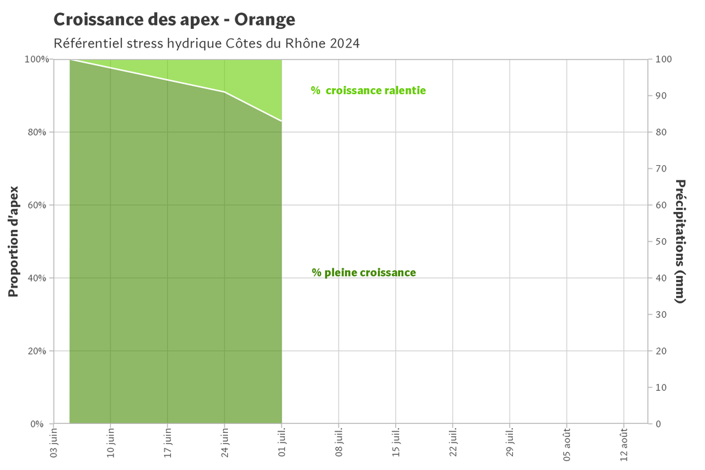

### Roquemaure

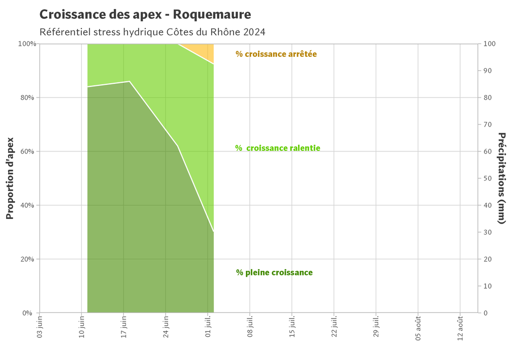

### Tavel

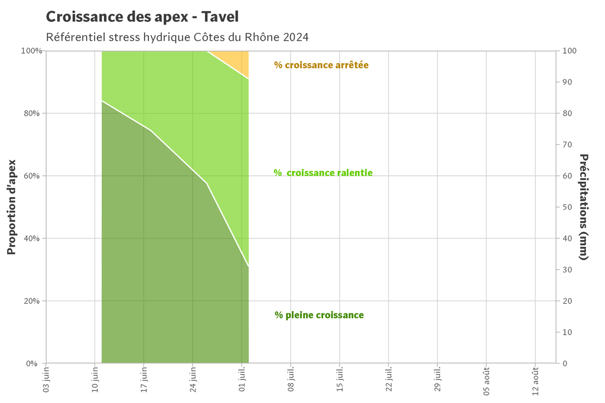

# Suivi des sondes capacitives

Des sondes capacitives ont été installées sur le réseau cette année. Ces sondes nous donnent le pourcentage d’humidité par horizons de sols. Il faut noter que d’une parcelle à une autre, les % peuvent varier notamment de part la texture du sol qui impacte la capacité du sol à retenir l’eau. Il peut être plus intéressant dans un premier temps, d’observer l’évolution des courbes et leur tendance générale pour savoir si le sol se déssèche. Prochainement, seront intégrés des graphiques de stock en mm, pour faciliter la compréhensions.

*Attention, les seuils de capacité au champs, de RFU, stress hydrique et flétrissement ont été fixés soit grâce à la texture du sol, soit en prenant compte du pourcentage maximum et minimum des sols cette année. Pour affiner ces seuils, il convient d’avoir un an de données pour plus de précision.*

### Cairanne

[figure not shown]

### Laudun

[figure not shown]

### Lirac

[figure not shown]

### Orange

[figure not shown]

### Piolenc

[figure not shown]

### Rasteau

[figure not shown]

### Roquemaure

[figure not shown]

### Sainte Cecile

[figure not shown]

### Vacqueyras

[figure not shown]

# Tensiomètre - Vénéjan

Nous disposons d’un tensiomètre à Vénéjan, et non d’une sonde capacitive. Celui-ci nous indique tout de même la facilité avec laquelle la plante va pouvoir extraire l’eau du sol.

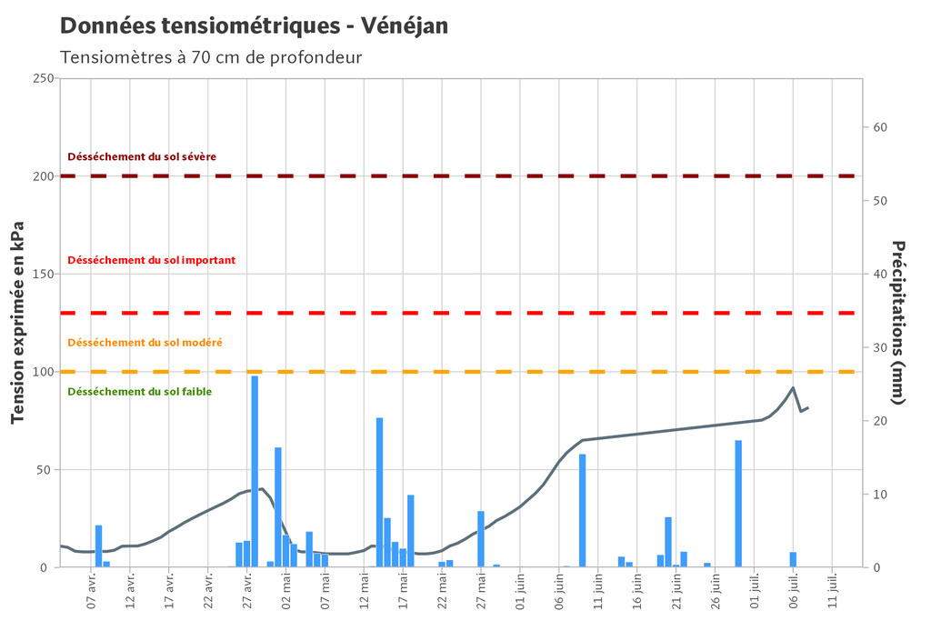